# Analysis of Obesity Factors in the United States

## What is Obesity?

Obesity is the category for an individual with an above average Body Mass Index, or BMI for short. BMI is used to measure the ratio between height and weight of an individual, and it's calculated by dividing a person's weight by the square of their height. A high BMI generally indicates high body fatness, but it is not a diagnosis of one's body health. However, BMI can be quickly computed and is correlated with direct measurements of body fat, making it an efficient indicator of one's weight class.

## Importance of Weight Control

Obesity is a "common, serious, and costly disease" according to the [CDC](https://www.cdc.gov/obesity/data/adult.html) and is growing in the United States. It can lead to a number of health complications if left unchecked, such as diabetes, strokes, and even cancer. Although obesity takes time to inflict damage, it's important to take steps that are consistent with a healthy lifestyle. This project will look for some of the factors that contribute to obesity in the U.S. and draw conclusions from these results.

## Purpose of this project

This project is designed to take you through the entire data pipeline, which consists of five steps:

1. Data Collection
2. Data Processing
3. Exploratory Analysis and Data Visualization
4. Analysis, Hypothesis testing, and ML
5. Insight and Policy Decision

## Data Collection and Curation

First things first, necessary libraries to execute the code need to be imported.

```python
import pandas as pd
import numpy as np
import math

from sklearn import linear_model

import matplotlib.pyplot as plt
```

This project will use a dataset from the Behavorial Risk Factor Surveillance System of the CDC. We can trust the data since the CDC is a government organization, and each row is only used if it's sample size is a significant portion of the population.

The dataset consists of aggregate responses received from questioning individuals from different states and territories.

```python
raw_df = pd.read_csv("drive/MyDrive/CMSC320/Obesity.csv")
raw_df.head()
```

|  | YearStart | YearEnd | LocationAbbr | LocationDesc | Datasource | Class | Topic | Question | Data_Value_Unit | Data_Value_Type | ... | GeoLocation | ClassID | TopicID | QuestionID | DataValueTypeID | LocationID | StratificationCategory1 | Stratification1 | StratificationCategoryId1 | StratificationID1 |
| --- | --- | --- | --- | --- | --- | --- | --- | --- | --- | --- | --- | --- | --- | --- | --- | --- | --- | --- | --- | --- | --- |
| 0 | 2020 | 2020 | US | National | Behavioral Risk Factor Surveillance System | Physical Activity | Physical Activity - Behavior | Percent of adults who engage in no leisure-tim... | NaN | Value | ... | NaN | PA | PA1 | Q047 | VALUE | 59 | Race/Ethnicity | Hispanic | RACE | RACEHIS |
| 1 | 2014 | 2014 | GU | Guam | Behavioral Risk Factor Surveillance System | Obesity / Weight Status | Obesity / Weight Status | Percent of adults aged 18 years and older who ... | NaN | Value | ... | (13.444304, 144.793731) | OWS | OWS1 | Q036 | VALUE | 66 | Education | High school graduate | EDU | EDUHSGRAD |
| 2 | 2013 | 2013 | US | National | Behavioral Risk Factor Surveillance System | Obesity / Weight Status | Obesity / Weight Status | Percent of adults aged 18 years and older who ... | NaN | Value | ... | NaN | OWS | OWS1 | Q036 | VALUE | 59 | Income | $50,000 - $74,999 | INC | INC5075 |
| 3 | 2013 | 2013 | US | National | Behavioral Risk Factor Surveillance System | Obesity / Weight Status | Obesity / Weight Status | Percent of adults aged 18 years and older who ... | NaN | Value | ... | NaN | OWS | OWS1 | Q037 | VALUE | 59 | Income | Data not reported | INC | INCNR |
| 4 | 2015 | 2015 | US | National | Behavioral Risk Factor Surveillance System | Physical Activity | Physical Activity - Behavior | Percent of adults who achieve at least 300 min... | NaN | Value | ... | NaN | PA | PA1 | Q045 | VALUE | 59 | Income | Less than $15,000 | INC | INCLESS15 |

5 rows × 33 columns

## Data Processing

Just from first glance there are quite a few problems with the dataset. Many of the columns are duplicated or only one value, and we may need to unmelt the data to be able to graph points equally.

First, let's drop all the columns that aren't necessary, then sort them by YearStart, LocationAbbr, and QuestionID.

```python
# Ideal dataset:
# State/Territory Year Obesity Overweight Physical_Activity_Low Physical_Activity_Moderate Physical_Activity_High Muscle_Strengthening Fruits Vegetables

# Drop the following columns since they are either
# 1. Duplicate or nearly a duplicate of another column
# 2. Only consist of one value
# 3. Too sparse to accurately draw conclusions

df = raw_df.drop(columns=["YearEnd",
                      "LocationDesc",
                      "Datasource",
                      "Class",
                      "Topic",
                      "Data_Value_Unit",
                      "Data_Value_Type",
                      "Data_Value_Alt",
                      "Low_Confidence_Limit",
                      "High_Confidence_Limit ",
                      "Sample_Size",
                      "Total",
                      "GeoLocation",
                      "ClassID",
                      "TopicID",
                      "DataValueTypeID",
                      "LocationID",
                      "StratificationCategory1",
                      "Stratification1",
                      "StratificationCategoryId1",
                      "StratificationID1",
                      "Data_Value_Footnote_Symbol",
                      "Data_Value_Footnote"
                      ])
df.sort_values(['YearStart', 'LocationAbbr', 'QuestionID'], ascending = True).head()
```

|  | YearStart | LocationAbbr | Question | Data_Value | Age(years) | Education | Gender | Income | Race/Ethnicity | QuestionID |
| --- | --- | --- | --- | --- | --- | --- | --- | --- | --- | --- |
| 21271 | 2011 | AK | Percent of adults aged 18 years and older who ... | 24.5 | NaN | NaN | NaN | $35,000 - $49,999 | NaN | Q036 |
| 21410 | 2011 | AK | Percent of adults aged 18 years and older who ... | NaN | NaN | NaN | NaN | NaN | Asian | Q036 |
| 24102 | 2011 | AK | Percent of adults aged 18 years and older who ... | 28.8 | NaN | Less than high school | NaN | NaN | NaN | Q036 |
| 25413 | 2011 | AK | Percent of adults aged 18 years and older who ... | 30.9 | NaN | NaN | NaN | NaN | American Indian/Alaska Native | Q036 |
| 26760 | 2011 | AK | Percent of adults aged 18 years and older who ... | 29.2 | 45 - 54 | NaN | NaN | NaN | NaN | Q036 |

That's a little better, but that's a lot of NaN values. Let's try to condense our data by merging all the data in each state for each question. We'll do this by adding columns for every kind of respondent type, and filling in the column as the data type for each respondent. Then we can keep one row and remove the rest.

```python
new_df = pd.DataFrame(columns=['YearStart', 'LocationAbbr', 'Question', 'Data_Value', 'Age(years)',
       'Education', 'Gender', 'Income', 'Race/Ethnicity', 'QuestionID',
       'Hispanic', 'Some college or technical school', '45 - 54',
       'Hawaiian/Pacific Islander', 'American Indian/Alaska Native',
       '$15,000 - $24,999', 'Non-Hispanic White', 'Male', 'College graduate',
       'Non-Hispanic Black', '35 - 44', 'Less than $15,000', 'Female',
       '$50,000 - $74,999', 'Other', '65 or older', '18 - 24',
       'Less than high school', '$75,000 or greater', '$35,000 - $49,999',
       '55 - 64', '2 or more races', 'Asian', '25 - 34', 'Data not reported',
       'High school graduate', '$25,000 - $34,999'])

for year in df["YearStart"].unique():
  for loc in df["LocationAbbr"].unique():
    for qid in df["QuestionID"].unique():
      beginning_index = -1
      for index, row in df[(df["YearStart"] == year) &
                              (df["LocationAbbr"] == loc) &
                              (df["QuestionID"] == qid)].iterrows():
        if beginning_index == -1:
          beginning_index = index
        if isinstance(row["Age(years)"], str):
          df.at[beginning_index, row["Age(years)"]] = row["Data_Value"]
        elif isinstance(row["Gender"], str):
          df.at[beginning_index, row["Gender"]] = row["Data_Value"]
        elif isinstance(row["Income"], str):
          df.at[beginning_index, row["Income"]] = row["Data_Value"]
        elif isinstance(row["Race/Ethnicity"], str):
          df.at[beginning_index, row["Race/Ethnicity"]] = row["Data_Value"]
        elif isinstance(row["Education"], str):
          df.at[beginning_index, row["Education"]] = row["Data_Value"]
      if beginning_index != -1:
        new_df.loc[len(new_df.index)] = df.loc[beginning_index]

new_df.head()
```

|  | YearStart | LocationAbbr | Question | Data_Value | Age(years) | Education | Gender | Income | Race/Ethnicity | QuestionID | ... | Less than high school | $75,000 or greater | $35,000 - $49,999 | 55 - 64 | 2 or more races | Asian | 25 - 34 | Data not reported | High school graduate | $25,000 - $34,999 |
| --- | --- | --- | --- | --- | --- | --- | --- | --- | --- | --- | --- | --- | --- | --- | --- | --- | --- | --- | --- | --- | --- |
| 0 | 2020 | US | Percent of adults who engage in no leisure-tim... | 30.6 | NaN | NaN | NaN | NaN | Hispanic | Q047 | ... | 41.1 | 12.7 | 24.2 | 26.0 | 21.2 | 20.4 | 18.8 | 26.9 | 29.9 | 29.8 |
| 1 | 2020 | US | Percent of adults aged 18 years and older who ... | 34.3 | NaN | NaN | NaN | $35,000 - $49,999 | NaN | Q036 | ... | 38.8 | 29.0 | 34.3 | 36.3 | 31.6 | 11.8 | 30.9 | 27.1 | 34.0 | 35.1 |
| 2 | 2020 | US | Percent of adults aged 18 years and older who ... | 36.2 | 45 - 54 | NaN | NaN | NaN | NaN | Q037 | ... | 33.6 | 37.0 | 35.5 | 37.1 | 32.3 | 31.0 | 32.7 | 34.0 | 34.2 | 34.0 |
| 3 | 2020 | GU | Percent of adults who engage in no leisure-tim... | 33.9 | 65 or older | NaN | NaN | NaN | NaN | Q047 | ... | 36.2 | 18.8 | 24.9 | 29.4 | 23.3 | 30.3 | 21.1 | 25.2 | 22.2 | 33.3 |
| 4 | 2020 | GU | Percent of adults aged 18 years and older who ... | 28.7 | NaN | NaN | NaN | Data not reported | NaN | Q036 | ... | 34.4 | 32.5 | 33.2 | 26.6 | 36.0 | 18.7 | 32.5 | 28.7 | 39.3 | 41.9 |

5 rows × 37 columns

A little more cleaning up. Now let's drop the columns between Data_Value and Race/Ethnicity since we don't need them anymore. Then we can rename the new columns as something easier to maintain.

```python
df = new_df.drop(columns=["Data_Value", "Age(years)", "Education", "Gender", "Income", "Race/Ethnicity"])
df.sort_values(["YearStart", "LocationAbbr", "QuestionID"])

df = df.rename(columns={
    "YearStart":"Year",
    "LocationAbbr":"Location"
})
df.head()
```

|  | Year | Location | Question | QuestionID | Hispanic | Some college or technical school | 45 - 54 | Hawaiian/Pacific Islander | American Indian/Alaska Native | $15,000 - $24,999 | ... | Less than high school | $75,000 or greater | $35,000 - $49,999 | 55 - 64 | 2 or more races | Asian | 25 - 34 | Data not reported | High school graduate | $25,000 - $34,999 |
| --- | --- | --- | --- | --- | --- | --- | --- | --- | --- | --- | --- | --- | --- | --- | --- | --- | --- | --- | --- | --- | --- |
| 0 | 2020 | US | Percent of adults who engage in no leisure-tim... | Q047 | 30.6 | 21.4 | 23.5 | 22.1 | 29.9 | 34.0 | ... | 41.1 | 12.7 | 24.2 | 26.0 | 21.2 | 20.4 | 18.8 | 26.9 | 29.9 | 29.8 |
| 1 | 2020 | US | Percent of adults aged 18 years and older who ... | Q036 | 36.6 | 34.1 | 38.1 | 38.5 | 38.8 | 36.1 | ... | 38.8 | 29.0 | 34.3 | 36.3 | 31.6 | 11.8 | 30.9 | 27.1 | 34.0 | 35.1 |
| 2 | 2020 | US | Percent of adults aged 18 years and older who ... | Q037 | 35.7 | 34.2 | 36.2 | 34.3 | 31.4 | 31.8 | ... | 33.6 | 37.0 | 35.5 | 37.1 | 32.3 | 31.0 | 32.7 | 34.0 | 34.2 | 34.0 |
| 3 | 2020 | GU | Percent of adults who engage in no leisure-tim... | Q047 | 16.2 | 26.9 | 26.9 | 26.9 | NaN | 22.5 | ... | 36.2 | 18.8 | 24.9 | 29.4 | 23.3 | 30.3 | 21.1 | 25.2 | 22.2 | 33.3 |
| 4 | 2020 | GU | Percent of adults aged 18 years and older who ... | Q036 | 35.7 | 33.2 | 38.1 | 48.4 | NaN | 38.2 | ... | 34.4 | 32.5 | 33.2 | 26.6 | 36.0 | 18.7 | 32.5 | 28.7 | 39.3 | 41.9 |

5 rows × 31 columns

```python
nan_df = pd.DataFrame(columns=["Column", "Total NaNs", "Percent of Column is NaN"])
for col in df.columns:
  nan_df.loc[len(nan_df.index)] = [col, df[col].isna().sum(), round(df[col].isna().sum() / len(df[col]), 4) * 100]
nan_df
```

|  | Column | Total NaNs | Percent of Column is NaN |
| --- | --- | --- | --- |
| 0 | Year | 0 | 0.00 |
| 1 | Location | 0 | 0.00 |
| 2 | Question | 0 | 0.00 |
| 3 | QuestionID | 0 | 0.00 |
| 4 | Hispanic | 133 | 4.19 |
| 5 | Some college or technical school | 26 | 0.82 |
| 6 | 45 - 54 | 26 | 0.82 |
| 7 | Hawaiian/Pacific Islander | 2970 | 93.57 |
| 8 | American Indian/Alaska Native | 1106 | 34.85 |
| 9 | $15,000 - $24,999 | 26 | 0.82 |
| 10 | Non-Hispanic White | 70 | 2.21 |
| 11 | Male | 26 | 0.82 |
| 12 | College graduate | 26 | 0.82 |
| 13 | Non-Hispanic Black | 660 | 20.79 |
| 14 | 35 - 44 | 26 | 0.82 |
| 15 | Less than $15,000 | 26 | 0.82 |
| 16 | Female | 26 | 0.82 |
| 17 | $50,000 - $74,999 | 31 | 0.98 |
| 18 | Other | 2136 | 67.30 |
| 19 | 65 or older | 26 | 0.82 |
| 20 | 18 - 24 | 26 | 0.82 |
| 21 | Less than high school | 26 | 0.82 |
| 22 | $75,000 or greater | 26 | 0.82 |
| 23 | $35,000 - $49,999 | 26 | 0.82 |
| 24 | 55 - 64 | 26 | 0.82 |
| 25 | 2 or more races | 284 | 8.95 |
| 26 | Asian | 1137 | 35.82 |
| 27 | 25 - 34 | 26 | 0.82 |
| 28 | Data not reported | 26 | 0.82 |
| 29 | High school graduate | 26 | 0.82 |
| 30 | $25,000 - $34,999 | 26 | 0.82 |

The first four columns have no missing data, which is very good since it means we can query any year, location, and question without the case of it not existing. However, there is a remarkably large amount of data missing from columns pertaining to Race/Ethnicity, even up to 94% of data missing in the case of Hawaiian/Pacific Islander. The plot below visualizes the disparities of NaN values in the dataset.

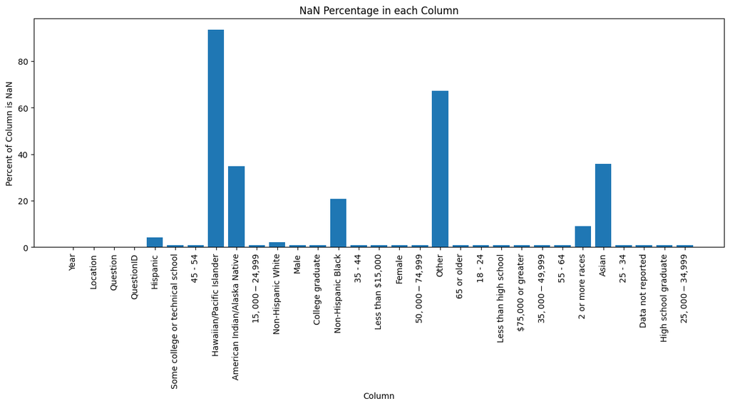

```python
nan_df.sort_values(["Percent of Column is NaN"], ascending=True)

plt.figure(figsize=(15, 5))
plt.title('NaN Percentage in each Column')
plt.xlabel('Column')
plt.ylabel('Percent of Column is NaN')

plt.bar(x=nan_df["Column"], height=nan_df["Percent of Column is NaN"])
plt.xticks(nan_df["Column"], rotation='vertical')
plt.show()
```

It should be pointed out that nearly all the other columns with 1% NaN percentage have the exact same number of NaN values: 26. This leads me to believe there are 26 faulty rows in the dataset, which we may have to fix. But first, we will have to get rid of the above columns. We cannot make any meaningful conclusions with such little information, and attempting to solve this by filling in the values with close guesses would unavoidably introduce substantial amounts of bias into our model.

I believe there is such little information in these columns simply because fewer people chose to share their race when being questioned for this dataset. There are also fewer American Indians and Hawaiians inside the U.S. than other ethnicities, which may be why they are the columns with the most missing data. This is just conjecture, but it might be an interesting question to explore in another project.

```python
print("Overall NaN (missing data) percentage before dropping Ethnicity/Race columns: {}%" \
      .format(round(df.isna().sum().sum() / (len(df) * (len(df.columns) - 1)), 5) * 100))
final_df = df.drop(columns=["Asian",
                      "Hispanic",
                      "Hawaiian/Pacific Islander",
                      "American Indian/Alaska Native",
                      "Non-Hispanic Black",
                      "Non-Hispanic White",
                      "Other",
                      "2 or more races"])
print("Overall NaN percentage after dropping Ethnicity/Race columns: {}%" \
    .format(round(final_df.isna().sum().sum() / (len(final_df) * (len(final_df.columns) - 1)), 5) * 100))
```

```
Overall NaN (missing data) percentage before dropping Ethnicity/Race columns: 9.447%
Overall NaN percentage after dropping Ethnicity/Race columns: 0.715%
```

Since there are too many states to be able to plot them all out, we will only focus on the data values for the US as a whole. This way we don't have to worry about a few states with missing data and we get a good representation of the country as if we had plotted the states values individually.

Each one of the questions has a unique ID to go along with it. Here is what each ID links to:

- Q018: Percent of adults who report consuming fruit less than one time daily
- Q019: Percent of adults who report consuming vegetables less than one time daily
- Q036: Percent of adults aged 18 years and older who have obesity
- Q037: Percent of adults aged 18 years and older who have an overweight classification
- Q043: Percent of adults who achieve at least 150 minutes a week of moderate-intensity aerobic physical activity or 75 minutes a week of vigorous-intensity aerobic activity (or an equivalent combination)
- Q044: Percent of adults who achieve at least 150 minutes a week of moderate-intensity aerobic physical activity or 75 minutes a week of vigorous-intensity aerobic physical activity and engage in muscle-strengthening activities on 2 or more days a week
- Q045: Percent of adults who achieve at least 300 minutes a week of moderate-intensity aerobic physical activity or 150 minutes a week of vigorous-intensity aerobic activity (or an equivalent combination)
- Q046: Percent of adults who engage in muscle-strengthening activities on 2 or more days a week
- Q047: Percent of adults who engage in no leisure-time physical activity

First let's create a function to easily plot out each question and its respondents answers, then we can visualize the data.

```python
# final_df[final_df["18 - 24"].isna()].sort_values(["Year", "Location", "QuestionID"], ascending=True)
def make_plot(QuestionID:str, Location:str):

  obes_df = final_df[(final_df["QuestionID"] == QuestionID) & (final_df["Location"] == Location)]
  sorted_rows = obes_df.sort_values(["Year"], ascending=True)
  plt.figure(figsize=(18, 4))

  # Plot for Age groups
  plt.subplot(1, 4, 1)
  plt.title('By Age Groups')
  plt.xlabel('Year')
  plt.ylabel('Percent of Population')

  line1 = plt.plot(sorted_rows["Year"], sorted_rows["18 - 24"], label='18 - 24')
  line2 = plt.plot(sorted_rows["Year"], sorted_rows["25 - 34"], label='25 - 34')
  line3 = plt.plot(sorted_rows["Year"], sorted_rows["35 - 44"], label='35 - 44')
  line4 = plt.plot(sorted_rows["Year"], sorted_rows["45 - 54"], label='45 - 54')
  line5 = plt.plot(sorted_rows["Year"], sorted_rows["55 - 64"], label='55 - 64')
  plt.legend(loc='upper left')

  # Plot for Education
  plt.subplot(1, 4, 2)
  plt.title('By Education Level')
  plt.xlabel('Year')
  plt.ylabel('Percent of Population')

  line1 = plt.plot(sorted_rows["Year"], sorted_rows["Less than high school"], label='Less than high school')
  line2 = plt.plot(sorted_rows["Year"], sorted_rows["High school graduate"], label = 'High school graduate')
  line3 = plt.plot(sorted_rows["Year"], sorted_rows["Some college or technical school"], label = 'Some college/tech school')
  line4 = plt.plot(sorted_rows["Year"], sorted_rows["College graduate"], label = 'College graduate')
  plt.legend(loc='upper left')

  # Plot for Income
  plt.subplot(1, 4, 3)
  plt.title('By Income')
  plt.xlabel('Year')
  plt.ylabel('Percent of Population')

  line1 = plt.plot(sorted_rows["Year"], sorted_rows['Less than $15,000'], label = '$15k<')
  line2 = plt.plot(sorted_rows["Year"], sorted_rows['$15,000 - $24,999'], label = '$15k-24k')
  line3 = plt.plot(sorted_rows["Year"], sorted_rows['$25,000 - $34,999'], label = '$25k-34k')
  line4 = plt.plot(sorted_rows["Year"], sorted_rows['$35,000 - $49,999'], label = '$35k-49k')
  line5 = plt.plot(sorted_rows["Year"], sorted_rows['$50,000 - $74,999'], label = '$50k-74k')
  line6 = plt.plot(sorted_rows["Year"], sorted_rows['$75,000 or greater'], label = '$75k+')
  plt.legend(loc='upper left')

  # Plot for Sex
  plt.subplot(1, 4, 4)
  plt.title('By Sex')
  plt.xlabel('Year')
  plt.ylabel('Percent of Population')

  line1 = plt.plot(sorted_rows["Year"], sorted_rows['Male'], label = 'Male')
  line2 = plt.plot(sorted_rows['Year'], sorted_rows['Female'], label = 'Female')
  plt.legend(loc='upper left')
  plt.show()
```